# clustering with k-means

### Laboratoire d'Etudes Statistiques et de Conception d'Applications et Logiciels

## Cedoriase Academy For Artificial Intelligence

#### +229 66233516 / cedoriaseacademy@lescal-soc.com

## Apprentissage non supervisé

## Segmentation de la clientèle par la méthode des k-means

### 0 Librairies

```python
from datetime import datetime, timedelta
import pandas as pd
#%matplotlib inline
import matplotlib.pyplot as plt
import numpy as np
import seaborn as sns

sns.set()
# Les graphiques au format Retina sont plus nets et lisibles
%config InlineBackend.figure_format = 'retina'

# Masquer les alertes
import warnings
warnings.filterwarnings("ignore")
```

#### 1 Importation des données

```python
tx_user = pd.read_csv('tx_user.csv',encoding = "ISO-8859-1")
tx_user.head()
```

|  | CustomerID | Recency |
| --- | --- | --- |
| 0 | 12346.0 | 325 |
| 1 | 12747.0 | 1 |
| 2 | 12748.0 | 0 |
| 3 | 12749.0 | 3 |
| 4 | 12820.0 | 2 |

```python
tx_user.shape
```

```
(3950, 2)
```

### NB : La récence désigne le nbre de jours séparant la dernière date d'achat d'un client de la date actuelle (ou date de l'étude). En d'autres termes c'est le nbre de jrs d'inactivité du client

- Après le clustering, nous aurons des segments (ou clusters) comme suit :

  Récence Faible: cluster des meilleurs clients car ils ont acheté récemment. (Nbre de jours d'inactivité : faible).

  Récence moyenne : cluster des meilleurs clients moyen en terme d'achat récent. (Nbre de jours d'inactivité : moyen)

  Récence élevée : cluster des clients moins intéressants en raison de leur dernière date d'achat lointaine. (Nbre de jours d'inactivité : élevé). (c'est justement sur ce cluster que les entreprises doivent doubler les efforts marketing afin d'amener les clients à acheter plus fréquemment).
- Méthodologie : Entraîner un modèle d'apprentissage automatique non supervisé pour identifier différents groupes (clusters) pour chaque client. L'algorithme utilisé est celui des k-means

#### 2- Exploration des données

- Statistiques descriptives de la récence

```python
tx_user.Recency.describe()
```

```
count    3950.000000
mean       90.778481
std       100.230349
min         0.000000
25%        16.000000
50%        49.000000
75%       142.000000
max       373.000000
Name: Recency, dtype: float64
```

##### Interprétation

- Le nombre de jours d'inctivité varie de 0 à 373
- L'inactivité moyenne est de 90 jours
- 75% des clients ont une durée d'inactivité inférieure à 142 jours

##### Représentation : Répartition de la récence

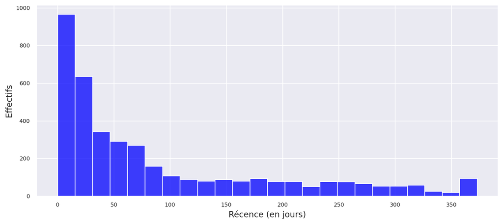

```python
plt.figure(figsize=(12, 5))
graph = sns.histplot(x='Recency', data=tx_user, color='blue')
graph.set(xlabel='Récence (en jours)', ylabel= 'Effectifs')
plt.tick_params(axis='both', which='major', labelsize=8)
```

##### Interprétation

- Il y a plus de clients actifs que de clients moins actifs

#### 3- Formation des clusters avec l'algorithme des K-means

- L'objectif est d'appliquer le clustering K-means pour attribuer un score de récence à chaque client.
- Nous devons indiquer le nombre de clusters souhaité à l'algorithme K-means : la méthode du coude est utilisée.

```python
from sklearn.cluster import KMeans

sse={}

tx_recency = tx_user[['Recency']]

for k in range(1, 10):
    kmeans = KMeans(n_clusters=k, max_iter=1000).fit(tx_recency)
    tx_recency["clusters"] = kmeans.labels_
    sse[k] = kmeans.inertia_
```

##### Représentation du graphe d'inertie

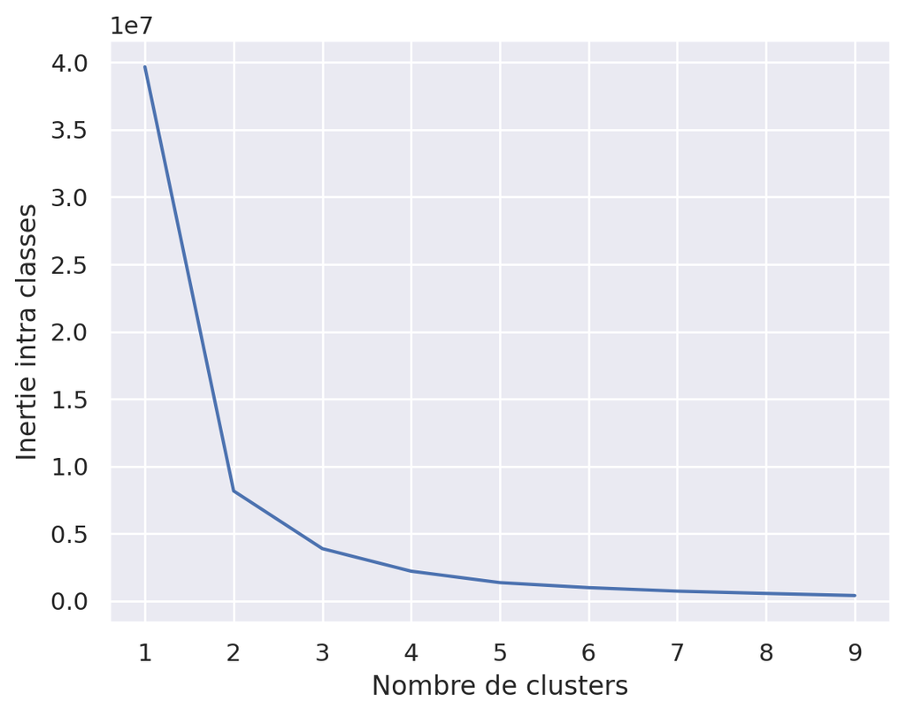

```python
plt.figure()
plt.plot(list(sse.keys()), list(sse.values()))
plt.xlabel("Nombre de clusters")
plt.ylabel("Inertie intra classes")
plt.show()
```

- Le nombre optimal de clusters correspond à celui à partir duquel l'inertie diminue beaucoup trop lentement. Nous pouvons choisir 4
- En fonction des besoins de l'entreprise, pour obtenir des classes plus fines nous pouvons choisir plus de clusters.

```python
kmeans = KMeans(n_clusters = 4)
kmeans.fit(tx_user[['Recency']])
```

```
KMeans(n_clusters=4)
```

- Nous rangeans chaque client dans le cluster prédit par l'algorithme K-means

```python
tx_user['RecencyCluster'] = kmeans.predict(tx_user[['Recency']])
tx_user
```

|  | CustomerID | Recency | RecencyCluster |
| --- | --- | --- | --- |
| 0 | 12346.0 | 325 | 0 |
| 1 | 12747.0 | 1 | 3 |
| 2 | 12748.0 | 0 | 3 |
| 3 | 12749.0 | 3 | 3 |
| 4 | 12820.0 | 2 | 3 |
| ... | ... | ... | ... |
| 3945 | 18280.0 | 277 | 0 |
| 3946 | 18281.0 | 180 | 2 |
| 3947 | 18282.0 | 7 | 3 |
| 3948 | 18283.0 | 3 | 3 |
| 3949 | 18287.0 | 42 | 3 |

3950 rows × 3 columns

- Définition d'une fonction pour ordonner les clusters

K-means attribue à chaque cluster un nombre mais pas de manière ordonnée. Nous ne pouvons pas dire que le cluster 0 est le pire et que le cluster 4 est le meilleur. La méthode order_cluster() le fait pour nous

```python
def order_cluster(cluster_field_name, target_field_name,df,ascending):
    new_cluster_field_name = 'new_' + cluster_field_name
    df_new = df.groupby(cluster_field_name)[target_field_name].mean().reset_index()
    df_new = df_new.sort_values(by=target_field_name,ascending=ascending).reset_index(drop=True)
    df_new['index'] = df_new.index
    df_final = pd.merge(df,df_new[[cluster_field_name,'index']], on=cluster_field_name)
    df_final = df_final.drop([cluster_field_name],axis=1)
    df_final = df_final.rename(columns={"index":cluster_field_name})
    return df_final
```

- Ordonner les clusters de récence

```python
tx_user = order_cluster('RecencyCluster', 'Recency',tx_user,False)
```

- Description des clusters de récence

```python
tx_user.groupby('RecencyCluster')['Recency'].describe()
```

| RecencyCluster | count | mean | std | min | 25% | 50% | 75% | max |
| --- | --- | --- | --- | --- | --- | --- | --- | --- |
| 0 | 478.0 | 304.393305 | 41.183489 | 245.0 | 266.25 | 300.0 | 336.00 | 373.0 |
| 1 | 568.0 | 184.625000 | 31.753602 | 132.0 | 156.75 | 184.0 | 211.25 | 244.0 |
| 2 | 954.0 | 77.679245 | 22.850898 | 48.0 | 59.00 | 72.5 | 93.00 | 131.0 |
| 3 | 1950.0 | 17.488205 | 13.237058 | 0.0 | 6.00 | 16.0 | 28.00 | 47.0 |

##### Interprétation

- Les clusters de récence ont des caractéristiques différentes : c'est l'objectif de la segmentation
- Les clients ayant effectué un achat récemment sont du cluster d'indice 3, ensuite d'indice 2; en témoignent les moyennes respectives du nombre de jours d'absence : 17 jours pour le cluster 3 et 77 pour le cluster 2

#### 4- Classement des clusters en trois catégories

Nous utilisons le critère de classification suivant :

```
• 0  : Inactivité élevée

• 1 : Inacativité moyenne

• 2+ : Inactivité faible
```

```python
tx_user['Cluster'] = 'Inactivité élevée'
tx_user.loc[tx_user['RecencyCluster']>0,'Cluster'] = 'Inacativité moyenne'
tx_user.loc[tx_user['RecencyCluster']>1,'Cluster'] = 'Inactivité faible'
```

```python
tx_user
```

|  | CustomerID | Recency | RecencyCluster | Cluster |
| --- | --- | --- | --- | --- |
| 0 | 12346.0 | 325 | 0 | Inactivité élevée |
| 1 | 12747.0 | 1 | 3 | Inactivité faible |
| 2 | 12748.0 | 0 | 3 | Inactivité faible |
| 3 | 12749.0 | 3 | 3 | Inactivité faible |
| 4 | 12820.0 | 2 | 3 | Inactivité faible |
| ... | ... | ... | ... | ... |
| 3945 | 18280.0 | 277 | 0 | Inactivité élevée |
| 3946 | 18281.0 | 180 | 1 | Inacativité moyenne |
| 3947 | 18282.0 | 7 | 3 | Inactivité faible |
| 3948 | 18283.0 | 3 | 3 | Inactivité faible |
| 3949 | 18287.0 | 42 | 3 | Inactivité faible |

3950 rows × 4 columns

#### Visualisation de la répartition des clusters

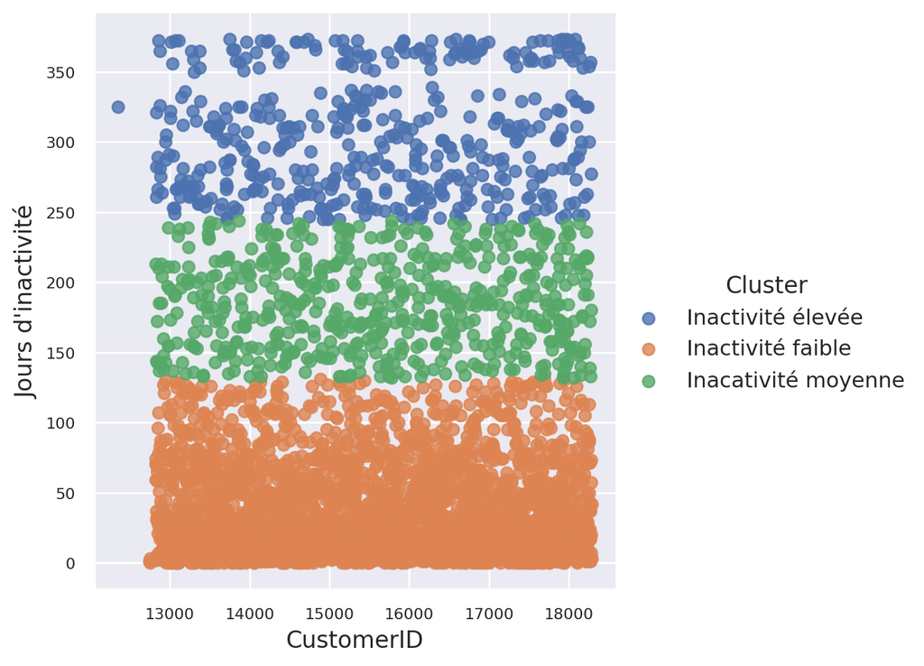

```python
plt.figure(figsize=(12, 5))
graph = sns.lmplot(data=tx_user, x="CustomerID", y="Recency",  hue="Cluster", fit_reg=False)
graph.set(xlabel="CustomerID", ylabel= "Jours d'inactivité")
plt.tick_params(axis='both', which='major', labelsize=8)
```

### 5 Suggestions

Cette segmentation peut nous permettre de mettre en oeuvre les stratégies suivantes. On se concentrera surtout sur le cluster d'inactivité élevée :

```
- Promotions ciblées à l'endroit des clients de ce cluster
- Etc.
```